# Biological Programming: R Basics

## Get help from documentations

You can get help from two types of documentations, tutorial (vignette) and reference manual. A tutorial helps a beginner to quickly get started using the package, whereas a reference manual lists all the details about the code and datasets included in the package for a more experienced user to look up.

You can get both tutorial and manual either using RStudio or online.

### Get documentations using RStudio

Following is a demo of how to use `vignette()` and `help()` functions.

```r
# I want to see the the vignette of DESeq2
# This does not require DESeq2 to be imported
vignette("DESeq2")

# I want to get help on the function DESeq() in DESeq2
# This requires DESeq2 to be imported. If we did not import DESeq2 previously,
# you will receive an error message.
help(DESeq)

# However, if you do not want to import DESeq but just want to see the documentation
# of DESeq(), you can use the following code
help(DESeq, package = "DESeq2")

# If you want to know more about these two functions, check their manuals
help(vignette)
help(help)
```

### Get documentations online

Google the package and go to either CRAN or Bioconductor depending on the package source. Find the documentations listed in the webpage. Following are the screenshots of the location of the documentation:

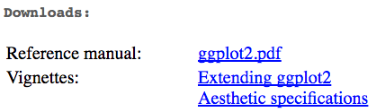

> `ggplot2` documentations at https://cran.r-project.org/web/packages/ggplot2/index.html

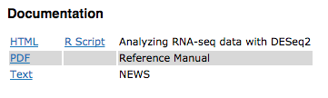

> `DESeq2` documentations at https://bioconductor.org/packages/release/bioc/html/DESeq2.html

The first documentation of DESeq2 on Bioconductor *Analyzing RNA-seq data with DESeq2* is the tutorial.

Documentations are usually very helpful, but also keep in mind that Google is your best friend when learning programming. There are many helpful Q&As on [StackOverflow](https://stackoverflow.com/) and [Biostars](https://www.biostars.org/). StackOverflow community is focused on general programming and statistics, whereas Biostars community is focused on bioinformatics.

# R Markdown

R Markdown is a markup language for formatting an analysis report written in R, which allows you to embed your R analysis code into a document explaining your analysis.

The R package [`knitr`](https://yihui.name/knitr/) converts R Markdown files into an easy-to-read report in HTML, PDF, or Word format.

To start using R Markdown in RStudio:

1. Click menu `File -> New File ->` **`R Markdown`**. Then, you will be prompted by a window to fill in some relevant parameters. In the `Default Output Format:` option, select [`HTML`](https://en.wikipedia.org/wiki/HTML) (**important**), which is the standard markup language for creating web pages. It worth taking time to read the explanations of each option. After clicking `OK`, a new R Markdown file will show up in a pane of RStudio.
2. Click the `Knit` option at the top of the Markdown file pane. Then, you will be prompted to save the R Markdown file. If you hit `Knit` for the first time, you will be prompted to install several packages that are required to run the “knitting” process. Install them.

[figure not shown]

3. Give the file a name such as `test` and save it anywhere you prefer. Then, you will see an `R Markdown` tab show up in the `Console` pane, and it starts running. When running, `knitr` executes all R code and generates an HTML report. After it is done, a new window containing the generated HTML report will show up. The report file will also be stored in the same directory as the R Markdown file.

If you want to generate your report in PDF, you will need to install an extra tool on your computer outside of RStudio. This tool, TeX, helps `knitr` to convert R Markdown into PDF. In order to get this tool, click the tiny triangle at the right side of `Knit` option and select `Knit to PDF`, and you will receive an error message in the R Markdown tab. Follow the instructions in the error message carefully to install the TeX distribution.

[figure not shown]

We will explore the features of R Markdown in the next section.

# R basic operations

In this section, we will go through the basic operations of R programming language by analyzing a simple and fake biological dataset. The dataset is stored in the file `cell_exp_proliferation.csv` within the lab 1 handout. You can open it with a text editor or Excel.

The dataset is collected in an experiment to study the correlation between the expression level of a gene and the proliferation rate of a cell line. In the hypothesis, this gene is able to decrease the proliferation rate of the cells. This dataset includes the expression levels of the gene in wild type, knock down, and over-expressed cells and their proliferation rates. Each condition has 10 biological replicates. Following is the data contained in `cell_exp_proliferation.csv`.

| Proliferation.Rate | Expression.Level | Condition |
| --- | --- | --- |
| 10.422538 | 2.912106 | Knock Down |
| 10.624962 | 1.672114 | Knock Down |
| 14.845919 | 2.090984 | Knock Down |
| 20.419040 | 2.594304 | Knock Down |
| 17.045714 | 2.035436 | Knock Down |
| 12.541448 | 2.829719 | Knock Down |
| 11.525131 | 2.547715 | Knock Down |
| 10.567788 | 1.700726 | Knock Down |
| 13.761701 | 1.954836 | Knock Down |
| 14.967113 | 2.113366 | Knock Down |
| 5.569469 | 14.036798 | Wild Type |
| 9.017781 | 8.017283 | Wild Type |
| 10.352420 | 8.161492 | Wild Type |
| 15.831499 | 12.402427 | Wild Type |
| 8.375767 | 11.738877 | Wild Type |
| 10.080793 | 4.734751 | Wild Type |
| 7.790262 | 11.745099 | Wild Type |
| 9.461258 | 15.078069 | Wild Type |
| 13.532137 | 3.907414 | Wild Type |
| 9.121692 | 12.117747 | Wild Type |
| 5.365265 | 24.108622 | Overexpression |
| 4.914866 | 24.470910 | Overexpression |
| 4.368023 | 23.133997 | Overexpression |
| 10.246739 | 26.334096 | Overexpression |
| 3.900205 | 22.750532 | Overexpression |
| 10.285317 | 22.365098 | Overexpression |
| 7.091778 | 20.609853 | Overexpression |
| 7.256476 | 17.658962 | Overexpression |
| 2.886242 | 21.826452 | Overexpression |
| 4.848592 | 27.436294 | Overexpression |

This analysis includes the following steps:

1. Create an R project.
2. Create an R Markdown file.
3. Load the dataset into R.
4. Analyze the loaded dataset:
   - Correlation between expression level and proliferation rate.
   - Compare expression levels between conditions.
   - Compare proliferation rates between conditions.
5. Output plots and tables.

**Important**: The things that you need to do are marked with **ACTION**.

## Create an R project

**ACTION**: Create a new `R project`: Click menu `File -> New Project -> Existing Directory ->` select the directory of lab 1 and 2 handout, which contains `cell_exp_proliferation.csv`, as the project working directory (**very important**) `->` create.

An `R project` is a session of RStudio, and the `working directory` is the directory where R interpreter starts running.

**ACTION**: After the project is created, type `dir()` and hit “enter” in your `Console` tab, you should see `"cell_exp_proliferation.csv"` included in the output together with some other files. The function `dir()` lists all files under the working directory of R.

## Create an R Markdown file in the project

**ACTION**: Create a new R Markdown file as described above, click menu `File -> Save`, and save it under lab 1 and 2 handout directory (**very important**).

The first section is your header, which is as following:

```
---
title: "Your Title"
author: "Your Name"
date: "Some Date"
output: html_document
---
```

Then it comes the first R code chunk named `setup`.

````
```{r setup, include=FALSE}
knitr::opts_chunk$set(echo = TRUE)
```
````

An R code chunk is in the following format:

````
```{r Your Code Chunk Name, yourCodeChunkParameters=yourParamterValue}
# Your R code to be evaluated by R interpreter.
print("Hello World!")
```
````

Only code in the code chunks will be executed. Everything outside code chunks will be formatted by `knitr` as plain text.

**ACTION**: Delete everything below this chunk, and we are going to create our own analysis R Markdown file.

## Load dataset into R environment

**ACTION**: Add a level 1 header below the `setup` code chunk to notify the start of the data loading section by adding the following text:

```
# Load dataset into R environment
```

The `#` at the beginning indicates that the line is a level one header. When `knitr` sees the `#` it will format it as the level 1 header in the output report. Similarly `##` indicates a level 2 header, `###` indicates a level 3 header, etc. More information about the formatting conventions can be found at http://rmarkdown.rstudio.com/authoring_basics.html.

**ACTION**: Add the following code chunk into the created R Markdown file to load the `cell_exp_proliferation.csv` into your environment:

````
```{r load dataset}
# Load the data of cell_exp_proliferation.csv into the variable exp_prolif_df
# 'df' in the end indicates that the variable is a dataframe
# stringsAsFactors=FALSE indicates that we do not want to convert strings into factors
exp_prolif_df <- read.csv("cell_exp_proliferation.csv", stringsAsFactors=FALSE)

# Print the data stored in variable exp_prolif_df
exp_prolif_df
```
````

The dataset is stored in a file named `cell_exp_proliferation.csv` under the same directory as the handout. A comma separated values (CSV) format is commonly used to store a table in plain text. CSV file can be opened by text editor, Excel, and RStudio. The units of proliferation rate and expression level are both arbitrary.

Each row is a biological replicate. The columns are the proliferation rate, expression level, and condition.

In this code chunk, we loaded `cell_exp_proliferation.csv` as a `dataframe` into R environment. “`R environment`” has been mentioned many times in this handout, and you might wonder what it really is.

### R environment

An `R environment` is associated with each R interpreter session, and it includes all variables that you can access in that R interpreter session.

A **important** behavior of `knitr` is that when knitting an R Markdown file (after clicking `Knit`), `knitr` starts a brand **new** R interpreter session and evaluates all code chunks from beginning to the end. As a result, `knitr` will not be able to access the variables in the `console` R interpreter environment.

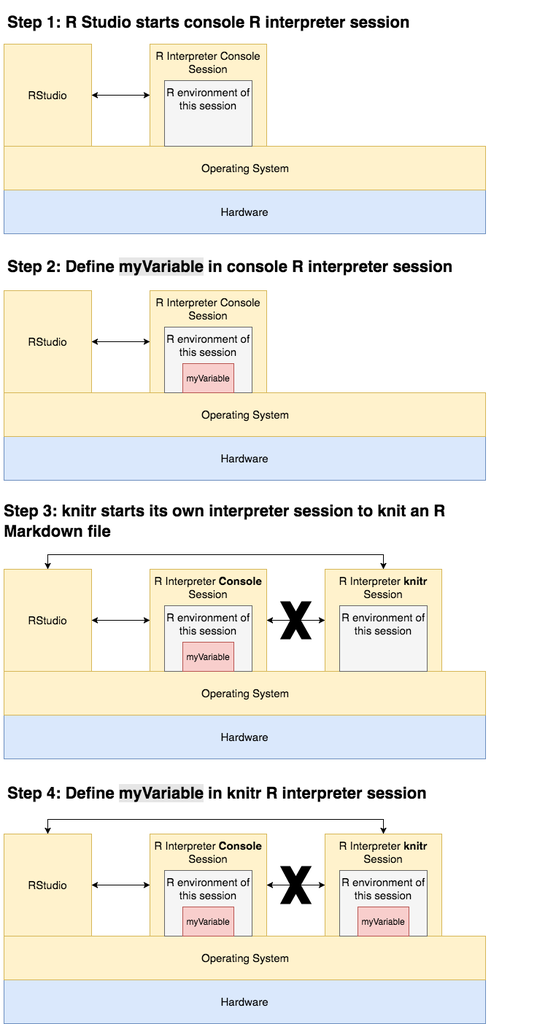

In the above figure, the R interpreter console session *cannot* access the variable `myVariable` in the `knitr` session, vice versa.

In the code chunk above, after the interpreter executes `exp_prolif_df <- read.csv("cell_exp_proliferation.csv", stringsAsFactors=FALSE)`, its environment will have an additional variable named `exp_prolif_df`. Then, we can print the values stored in that variable in that interpreter session.

However, you cannot print `exp_prolif_df` in your console session even after knitting the current document, because `knitr` starts a new session when `knitting` an document.

Similarly, if you import a library in an interpreter session, all code and datasets will be imported to its associated R environment, and you can use the imported code and datasets in that interpreter session. However, if you quit the current interpreter session and starts a new one, you will need to import that package again before using its code and datasets. Recall that when an R interpreter session started, only a minimum set of packages are imported into its environment.

In addition to the functions and datasets, an R environment also keeps track of many system parameters such as the library location, and the most important one is the **current working directory (CWD)**. You might wonder why it is very important to create the R project and R Markdown files in the lab handout directory, and the reason is that the locations of the R project and R Markdown file are the CWDs of the `Console` R interpreter session and `knitr` interpreter session respectively.

If your **CWD** does not include `cell_exp_proliferation.csv`, you will receive an error when running `exp_prolif_df <- read.csv("cell_exp_proliferation.csv", stringsAsFactors=FALSE)`, because R interpreter cannot find the file `cell_exp_proliferation.csv`.

You can change your CWD by clicking menu `Session -> Set Working Directory -> Choose Directory`.

### File path

The locations of files on your computer are specified by their **paths**.

A path describes the exact method to find your file. For example, if you want to find a file named `myFile.txt` under a directory called `myDirectory` under C disk directory in Windows, you need to open C disk and open `myDirectory`, and you will see `myFile.txt`. The path of this file is `C:\myDirectory\myFile.txt` .

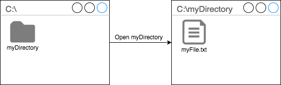

Paths separate different files (folder is a special kind file) that you need to open by `/` in MacOS/Linux and by `\` in Windows.

Following are some example paths on Windows, Mac, and Linux.

- Windows path of a file named `very_important_file.txt` under the C disk directory:

  ```
  C:\very_important_file.txt
  ```

- Windows path of a file named `not_important_file.txt` under a directory called `outdated_files` under C disk directory:

  ```
  C:\outdated_files\not_important_file.txt
  ```

- Mac path of file named `very_important_file.txt` under your Documents directory:

  ```
  /Users/yourUserName/Documents/very_important_file.txt
  ```

- Mac path of file named `not_important_file.txt` under a directory called `outdated_files` under your Documents directory:

  ```
  /Users/yourUserName/Documents/outdated_files/not_important_file.txt
  ```

- Linux path of file named `very_important_file.txt` under your Documents directory:

  ```
  /home/yourUserName/Documents/very_important_file.txt
  ```

- Linux path of file named `not_important_file.txt` under a directory called `outdated_files` under your Documents directory:

  ```
  /home/yourUserName/Documents/outdated_files/not_important_file.txt
  ```

The way how `knitr` R interpreter finds `cell_exp_proliferation.csv` is through a path **relative** to CWD. `read.csv("cell_exp_proliferation.csv")` asks R interpreter to find `cell_exp_proliferation.csv` under CWD. You can check your CWD path by typing `getwd()` in `Console` tab and hit “enter”. If a path is specified without `/` on MacOS/Linux or `DiskLetter:\` on Windows, it will be prepended with the path of CWD to form an **absolute** path, and R interpreter will further look up that absolute path. If the file specified by the absolute path does not exist, an error message will be prompted stating that the file is not found.

Following is an example of how R **failed** to find `cell_exp_proliferation.csv`:

- CWD path of an R interpreter session: `/home/youUserName/Documents/someOtherDirectory`, and this directory does **not** contain the file `cell_exp_proliferation.csv`.
- Relative path R tries to find when we running `read.csv("cell_exp_proliferation.csv")` on the R session: `cell_exp_proliferation.csv`.
- Absolute path R tries to find when we running `read.csv("cell_exp_proliferation.csv")` on the R session: `/home/youUserName/Documents/someOtherDirectory/cell_exp_proliferation.csv`.
- Because `/home/youUserName/Documents/someOtherDirectory/cell_exp_proliferation.csv` does not exist, an error message will be prompted.

There are two special cases of relative paths:

- `.` refers to the CWD.
- `..` refers the directory at the immediate upper level of CWD.

For example, when CWD is `/home/youUserName/Documents/someOtherDirectory`:

- The absolute path of `.` is the same as CWD: `/home/youUserName/Documents/someOtherDirectory`
- The absolute path of `..` is the immediate upper level directory of CWD: `/home/youUserName/Documents`
- The absolute path of `../someOtherDirectory` is the same as CWD.
- The absolute path of `./.` is the same as CWD.

**Important** note on specifying a path in R on Windows:

If you are running R interpreter on Windows, and you specified a path using a string, you have to use two backslashes `\\` in an R string for one backslash `\` in its corresponding path. For example, the absolute path of a file is `C:\aFile.txt`, and the R string to represent this path is `"C:\\aFile.txt"`. This is because R treats backslash `\` as a special character in string, so we have to use `\\` to represent the real character `\` in R strings. There are many rules listed in the following website, https://stat.ethz.ch/R-manual/R-devel/library/base/html/Quotes.html . You do not have to read this now. Use this website as a reference.

Alternatively, replace `\` with `/` in the R string representing path, i.e. `"C:/aFile.txt"`, will also work. This is one of the *ad hoc* but convenient features in R programming language. See the following post fore more details, https://stackoverflow.com/a/14335218/4638182 .

## Analyze the loaded dataset

### Check linear correlation

**ACTION**: Add a level 1 header to notify the start of data analysis section:

```
# Analyze the loaded dataset
```

**ACTION**: Add a level 2 header to notify the start of linear correlation analysis:

```
## Check linear correlation between gene expression level and cell proliferation rate
```

**ACTION**: Add the following code to create a scatter plot of expression level versus proliferation rate:

````
```{r plot linear correlation}
# Import the package ggplot2
library(ggplot2)

# Create a scatter plot of expression level versus proliferation with linear regression line
lin_cor_plot <- ggplot(data = exp_prolif_df,
                       mapping = aes(x = Proliferation.Rate,
                                     y = Expression.Level)) +
  geom_point(aes(color = Condition)) +
  geom_smooth(method="lm", se = FALSE) +
  labs(x = "Proliferation Rate", y = "Expression Level", color = "Condition")

# Display the plot. The function call print() is optional.
print(lin_cor_plot)
```
````

**ACTION**: Knit the document by clicking `Knit`.

In this code chunk, we imported `ggplot2` and created a scatter plot using it. We will talk more about making plots using `ggplot2` in later lab sessions. The code is explained line by line as the following:

- `lin_cor_plot <- ggplot(data = exp_prolif_df, mapping = aes(x = Proliferation.Rate, y = Expression.Level))`:
  - Note that a code expression can be written in multiple lines following certain rules. The three most commonly used rules are **1)** change line after a comma “`,`” to specify more parameters in a function call, **2)** change line after an operator such as `+`, **3)** change line after `{` when defining a function and writing a loop.
  - `lin_cor_plot <- ggplot()`: The function `ggplot()` is called to make a new plot and store that plot in variable `lin_cor_plot`.
  - `data = exp_prolif_df`, specifies that the dataset we are plotting is variable `exp_prolif_df`.
  - `mapping = aes(x = Proliferation.Rate, y = Expression.Level)` specifies that we want to plot the column `Proliferation.Rate` in x-axis and the column `Expression.Level` in the y-axis.
  - **NOTE**: that there is a `+` at the end of line, which indicates that the plotting is not ended yet.
- `geom_point(aes(color = Condition))`:
  - `geom_point()`: make a scatter plot.
  - `aes(color = Condition)`: color the points according to the `Condition` column.
- `geom_smooth(method="lm", se = FALSE)`:
  - `geom_smooth`: add a regression line to the scatter plot.
  - `method = lm`: use linear regression. `lm` refers to the function `lm()` that is used to fit a linear model.
  - `se = FALSE`: do not plot the confidence intervals of the linear regression.
- `labs(x = "Proliferation Rate", y = "Expression Level", color = "Condition")`
  - `labs()`: label the plot.
  - `x = "Proliferation Rate"`: label x-axis as `Proliferation Rate`.
  - `y = "Expression Level"`: label y-axis as `Expression Level`.
  - `color = "Condition"`: label the color of points as `condition`.
  - **NOTE**: Because there is no `+` at the end of the line, this line concludes the code expression to create the plot.

**ACTION**: Add the following code chunk to print out the statistics of the linear regression:

````
```{r print linear correlation stats}
# Print the statistics of linear regression
summary(lm(Expression.Level ~ Proliferation.Rate, data = exp_prolif_df))
```
````

**ACTION**: Knit the document by clicking `Knit`.

Code explanation:

- `summary(lm(Expression.Level ~ Proliferation.Rate, data = exp_prolif_df))`:
  - `summary()`: summarize `lm(Expression.Level ~ Proliferation.Rate, data = exp_prolif_df)`
  - `lm()`: fit a linear model.
  - `Expression.Level ~ Proliferation.Rate`: the formula of the linear model, which specifies that we want the linear model to be `Expression.Level` column versus `Proliferation.Rate` column.
  - `data = exp_prolif_df`: the dataset is variable `exp_prolif_df`.

The **p-value** of the linear regression will be printed in the last line of the linear model stats.

### Test gene expression level differences

The purpose of this analysis is to validate that the gene is knocked down or overexpressed.

**ACTION**: Add a level 2 header to notify the start of expression level comparisons:

```
## Compare gene expression levels between different conditions
```

**ACTION**: Add a code chunk to create a boxplot of the expression levels of all conditions:

````
```{r plot gene exp}
# Create boxplot of gene expression levels
exp_boxplot <- ggplot(data = exp_prolif_df,
                      aes(x = Condition, y = Expression.Level,
                          color = Condition)) +
  geom_boxplot() +
  geom_dotplot(aes(fill = Condition), binaxis='y',
               stackdir='center', binwidth = 1, dotsize = 0.75) +
  labs(x = 'Condition', y = 'Expression Level')

exp_boxplot
```
````

**ACTION**: Knit the document by clicking `Knit`.

Each box in the plot refers to a condition, and the dots are the measured expression levels stacked into bins.

Code explanation:

- `ggplot(data = exp_prolif_df, aes(x = Condition, y = Expression.Level, color = Condition)) +`: similar as previously mentioned.
- `geom_boxplot() +`: make a boxplot
- `geom_dotplot(aes(fill = Condition), binaxis='y', stackdir='center', binwidth = 1, dotsize = 0.75) +`:
  - `geom_dotplot()`: make a [dotplot](http://ggplot2.tidyverse.org/reference/geom_dotplot.html) on top of the box plot.
  - `aes(fill = Condition)`: fill the dots according to their conditions.
- `labs(x = 'Condition', y = 'Expression Level')`: similar as previously mentioned.

**ACTION**: Add a code chunk to test the difference between each condition using t-test.

````
```{r test exp mean diff, message=FALSE}
library(dplyr)
# Select the expression levels of each condition and store them into individual variables.
wt_exp <- exp_prolif_df[exp_prolif_df$Condition == 'Wild Type', 'Expression.Level']
kd_exp <- subset(exp_prolif_df, Condition == 'Knock Down', select = 'Expression.Level', drop = TRUE)
oe_exp <- filter(exp_prolif_df, Condition == 'Overexpression') %>% pull(Expression.Level)

# knock down versus wild type
t.test(x = kd_exp, y = wt_exp, alternative = 'l')

# wild type versus overexpression
t.test(x = wt_exp, y = oe_exp, alternative = 'l')

# knock down versus overexpression
t.test(x = kd_exp, y = oe_exp, alternative = 'l')
```
````

**ACTION**: Knit the document by clicking `Knit`.

The p-values will be printed out.

Code explanation:

Then, we used t-test to test for the differences of expression level between conditions.

- `t.test(x = wt_exp, y = oe_exp, alternative = 'l')`
  - `x = wt_exp, y = oe_exp`: compare values in `wt_exp` and `oe_exp`.
  - `alternative = 'l'`: alternative hypothesis of this test is that the mean of `wt_exp` is less than `oe_exp`.
  - Look at the documentation of `t.test` for more details.

When performing t-test, we selected the expression levels and stored them into different variables. This procedure belongs to “data manipulation”. Following is a brief introduction to data manipulation, and we are going to cover more of it in future lab sessions.

#### Data manipulation

Data manipulation is a very general practice when doing data analysis, in which data in one form are turned into another form in order to complete the following analysis. For example, in this analysis, we have to extract the expression values from `exp_prolif_df` to complete t-tests.

There are basically 3 ways of data manipulation:

- Select or filter: select certain data points of interest from a bigger dataset.
- Summarize: calculate summary statistics, such mean and standard deviation, of multiple data points.
- Reshape: change the “design” of a table. There are two types of table “design”, “wide” and “long” format. One format can be “reshaped” into another using packages like [`reshape2`](https://cran.rstudio.com/web/packages/reshape2/index.html) and [`tidyr`](https://cran.r-project.org/web/packages/tidyr/index.html).
  - “Wide” table: this “design” exploits the relationship between your data, where the expression level of same set of genes are measured in three cell lines. With this relationship, you do not need to create three individual tables with only one gene or one cell line in each table. You can think of this design as “relational” format, which is not an exact technical term.

    | geneName | expressionInCellLineA | expressionInCellLineB | expressionInCellLineC |
    | --- | --- | --- | --- |
    | GeneA | 1 | 20 | 5 |
    | GeneB | 5 | 5 | 20 |
    | GeneC | 10 | 15 | 30 |

  - “Long” table: this “design” intends to make a “dictionary” of the data points (expression levels). If you want to look up for the expression level of `GeneA` in cell line A, find the rows with `geneName` column containing value `GeneA`, and then find the row with `cellLine` column containing value `expressionInCellLineA`. Then, you find the value you want. You can think of this design as “key-value store” format, which is also not an exact technical term. The “key” refers to the unique identifier of a data point, and “value” refers to the value of that data point.

    | geneName | cellLine | expressionLevel |
    | --- | --- | --- |
    | GeneA | expressionInCellLineA | 1 |
    | GeneB | expressionInCellLineA | 5 |
    | GeneC | expressionInCellLineA | 10 |
    | GeneA | expressionInCellLineB | 20 |
    | GeneB | expressionInCellLineB | 5 |
    | GeneC | expressionInCellLineB | 15 |
    | GeneA | expressionInCellLineC | 5 |
    | GeneB | expressionInCellLineC | 20 |
    | GeneC | expressionInCellLineC | 30 |

  - melt/gather/stack: Convert wide format to long format.
  - dcast/spread/unstack: Convert long format to wide format.
  - An analysis might be more easily done if the data is in either wide or long format. For more details, check this introduction to the R package `reshape2`, http://seananderson.ca/2013/10/19/reshape.html .

### Test cell proliferation rate differences

**NOTE**: I **strongly** encourage you to write the headers and code chunks of this section yourself before using the code we provide below, because this analysis is the same as the previous section on expression level analysis. **Hint**: You can make a copy the previous section and change all parameters or variable names related to expression level into proliferation rate.

**ACTION**: Add a level 2 header to notify the start of proliferation rate comparisons:

```
## Compare proliferation rates between different conditions
```

**ACTION**: Add a code chunk to create a boxplot of the proliferation rates of all conditions:

````
```{r plot proliferation rate}
# Create boxplot of proliferation rates
prolif_boxplot <- ggplot(data = exp_prolif_df,
                         aes(x = Condition, y = Proliferation.Rate,
                             color = Condition)) +
  geom_boxplot() +
  geom_dotplot(aes(fill = Condition), binaxis='y',
               stackdir='center', binwidth = 1, dotsize = 0.75) +
  labs(x = 'Condition', y = 'Proliferation Rate')

prolif_boxplot
```
````

**ACTION**: Knit the document by clicking `Knit`.

**ACTION**: Add a code chunk to test the difference between each condition using t-test.

````
```{r test proliferation rate diff}
# Select the proliferation rates of each condition and store them into individual variables.
wt_prolif <- exp_prolif_df[exp_prolif_df$Condition == 'Wild Type', 'Proliferation.Rate']
kd_prolif <- subset(exp_prolif_df, Condition == 'Knock Down', select = 'Proliferation.Rate', drop = TRUE)
oe_prolif <- filter(exp_prolif_df, Condition == 'Overexpression') %>% pull(Proliferation.Rate)

# knock down versus wild type
t.test(x = kd_prolif, y = wt_prolif, alternative = 'g')

# wild type versus overexpression
t.test(x = wt_prolif, y = oe_prolif, alternative = 'g')

# knock down versus overexpression
t.test(x = kd_prolif, y = oe_prolif, alternative = 'g')
```
````

**ACTION**: Knit the document by clicking `Knit`.

## Output plots and tables

Finally, we output the plots and tables for the record.

**ACTION**: Add a level 1 header to indicate the start of output section.

```
# Output results and plots
```

**ACTION**: Add a code chunk to save the plots we made.

````
```{r output plots, results='hide'}
# Save plot in a PDF file named cell_prolif_exp_plots.pdf
# You can also output your plots **individually** in other formats using other
# functions, such as bmp(), jpeg(), and png(). Check the documentation of the
# png() function for more details.
pdf('cell_prolif_exp_plots.pdf')

# Now, the following plots will be printed into cell_prolif_exp_plots.pdf .
lin_cor_plot
exp_boxplot
prolif_boxplot
# dev.off() tells R that we are done saving plots into cell_prolif_exp_plots.pdf .
dev.off()
```
````

**ACTION**: Knit the document by clicking `Knit`.

You should see a PDF file named `cell_prolif_exp_plots.pdf` generated in your CWD. You can open it using your file browser.

**ACTION**: Add a code chunk to calculate the mean and standard deviation of the data and output it into a table.

````
```{r output stats, results='hide'}
# Calculate summary statistics of all conditions
exp_prolif_stats_df <- exp_prolif_df %>%
  group_by(Condition) %>%
  summarise(expLevelMean = mean(Expression.Level),
            expLevelSd = sd(Expression.Level),
            prolifRateMean = mean(Proliferation.Rate),
            prolifRateSd = sd(Proliferation.Rate))

# Output the summary statistics table
write.csv(exp_prolif_stats_df, 'exp_prolif_stats.csv',
          row.names = FALSE)
```
````

**ACTION**: Knit the document by clicking `Knit`.

You should see a CSV file named `exp_prolif_stats.csv` generated in your CWD. You can open it using text editor or Excel.

This concludes our data analysis.

# Advantages of using R for data analysis comparing to Excel

There are many reasons why you might want to use R for your data analysis rather than Excel, and I will only compare their reproducibility, efficiency, and feasibility. There are definitely disadvantages of using R as well, such as time consuming to learn, but I will not elaborate on them

R Markdown analysis is much easier to be reproduced, because the same analysis can be done by anyone, including yourself after several months, with the R Markdown file and dataset by clicking `Knit`, and they are guaranteed to have the same results as yours. However, if someone wants to reproduce your data analysis using Excel, that person needs to click and type through the whole analysis, and errors might be introduced during analysis, which might fail that person to reproduce your results.

Using R Markdown is also more efficient than Excel:

- There are numerous ready-to-run R packages for you to use when analyzing your data. However, when using Excel, you might need to type a a lot of complicated formulas.
- When using R Markdown, you can write the analysis report during analysis, and everything will be formatted by `Knitr`. However, when using Excel, you need to write your report in Word or some other tools, which takes some time for formatting your tables and plots.
- When using R Markdown, you can try out your random analysis idea fairly quickly.
- Using R Markdown, you can validate the correctness of you analysis more easily, because the code are written sequentially. However, when using Excel, the order of your operations cannot be easily inferred from the spreadsheets, and you might have to go through each entry to look for your formula.

When analyzing some datasets, it is simply not feasible to use Excel. When the the size of data you are analyzing is more than 500MB, which is not very uncommon in biological data analysis, it might take several minutes for simply one operation in Excel, such as open, save, copy, paste, and delete. When using R, the same operations are much faster. There are also performance limits of R, but it is more rarely to reach those limits. When you reach the performance limits of R, it will be almost impossible to do the same analysis in Excel.

# References

Best, Ben. (2014) 2018. *Rmarkdown-Example: R Markdown Example Showing Figures & Tables with Captions, Equations, Inline R Values and References with a Zotero Library*. https://github.com/bbest/rmarkdown-example.

“Bioconductor.” 2017. *Wikipedia*. https://en.wikipedia.org/w/index.php?title=Bioconductor&oldid=816349709.

“Bioconductor - Install.” 2018. Accessed January 7. http://bioconductor.org/install/.

“HTML.” 2017. *Wikipedia*. https://en.wikipedia.org/w/index.php?title=HTML&oldid=815581603.

“Markdown.” 2018. *Wikipedia*. https://en.wikipedia.org/w/index.php?title=Markdown&oldid=818404099.

“Markdown Basics.” 2018. Accessed January 7. http://rmarkdown.rstudio.com/authoring_basics.html.

Morandat, Floréal, Brandon Hill, Leo Osvald, and Jan Vitek. 2012. “Evaluating the Design of the R Language.” In *ECOOP 2012 – Object-Oriented Programming*, 104–31. Lecture Notes in Computer Science. Springer, Berlin, Heidelberg. doi:10.1007/978-3-642-31057-7_6.

“Path (Computing).” 2017. *Wikipedia*. https://en.wikipedia.org/w/index.php?title=Path_(computing)&oldid=797542097.

“Spread a Key-Value Pair Across Multiple Columns. — Spread • Tidyr.” 2018. Accessed January 7. http://tidyr.tidyverse.org/reference/spread.html.

“Using R Markdown for Class Reports.” 2018. Accessed January 7. http://www.stat.cmu.edu/~cshalizi/rmarkdown/.

Wickham, Hadley. 2014. *Advanced R*. 1 edition. Boca Raton, FL: Chapman and Hall/CRC.